# Reproducibility & Better than Reproducibility II (repro 3 & 4)

Jeffrey Walker

2023-12-18

# Reproducibility II

## Dataset 1: Tryptophan metabolism drives dynamic immunosuppressive myeloid states in IDH-mutant gliomas

**Motivation for this dataset**: Effectively all examples of glm for counts that I find in the bench biology literature are on gene expression data and analyzed one of several very specialized packages in R that were developed for genomic data. In other words, in these big research teams, the team members doing the genomics understand GLMs and are fitting GLMs but the team members fitting models to non-genomic counts don’t seem to know what GLMs and so fit linear models or do non-parametric tests. It’s like team members don’t actually communicate with each other on the different parts of a paper. Anyway, here is an example of a glm fit to count data (converted to a proportion) for something other than gene expression! Yaaaay!

**Source article**: [Friedrich, Mirco, et al. “Tryptophan metabolism drives dynamic immunosuppressive myeloid states in IDH-mutant gliomas.” Nature Cancer 2.7 (2021): 723-740.](https://www.nature.com/articles/s43018-021-00201-z)

**Motivation for experiment in fig 2F**: The authors found patterns of myeloid cell type in human “high grade” gliomas (HGG) were dependent on the glioma tumor cell genotype at the IDH locus (WT vs. IDH mutant). They want to investigate this in an IDH mutant mouse model. A **glioma** is a tumor in the CNS (brain or spinal cord). These tumors are invaded by myeloid white blood cells, including microglia, monocytes, macrophages (moM$\Phi$), dendritic cells (DCs).

**Author’s reported result**: “Comparative analysis considering cell type and IDH status of experimental HGG between d7 and d28 revealed a drop in relative microglia content accompanied by a concomitant increase in macrophage and DC numbers in IDH-mutant HGG, suggesting a higher influx of circulating immune cells between early and late time points in these HGG. Importantly, these differences were not a result of differential tumor growth (Fig. 2e,f and Extended Data Fig. 3e). Based on these observations, we hypothesized that, dependent on their IDH status, microglia shaped by the early HGG microenvironment drive differential recruitment of invading immune cells, particularly blood-borne macrophages.”

**Source File**: tryptophan_fig2f.xlsx

**Repro Figure**: 2F (microglia only)

**Response variable**: microglia_percent (percent of all cells composed of microglia cell type – do microglia only!)

**important** – Assume that the early and late samples are different preps. Also the tumors come from four mice so there is lack of independence but ignore this.

**Assignment**:

1. Reproduce the statistics given by the authors for the analysis of microglia in Fig 2f
   - They use separate plots for WT and mutant – don’t reproduce this, but include in the same plot.
   - They give p < 0.001 for the early-late comparison in the mutant group. I get p = 0.0012.
2. Plot the model using ggplot_the_response. Give the plot pretty x-axis and y-axis labels. See the section in the [Plotting Models](https://www.middleprofessor.com/files/bio413/applied_biostatistics/plotting-models.html#how-to-use-the-plot-the-model-functions) chapter in the textbook on using ggplot_the_response to understand the arguments of the functions. This plot will look something like the published plot but will be a little different and better.
3. Better than reproducibility - We **should not** follow the authors and use the negative binomial for this response variable, why?
4. Is this inference by the authors justified: “Comparative analysis considering cell type and IDH status of experimental HGG between d7 and d28 revealed a drop in relative microglia content accompanied by a concomitant increase in macrophage and DC numbers in IDH-mutant HGG, suggesting a higher influx of circulating immune cells between early and late time points in these HGG”

### My Code and annotation

**Researcher’s method**: (from caption of Figure 2) “P values were calculated by fitting a negative binomial function to the percentage of cells as a function of the time point and cell type followed by post hoc comparison between time points using the emmeans method in R with multiple-testing adjustment using the Tukey method”

Note

1. The authors seem to have actually used a “binomial” and not negative binomial. I didn’t recognize this until I sleuthed it out after I created the assignment - the published CIs were the clue. See below.

```r
data_from <- "Tryptophan metabolism drives dynamic immunosuppressive myeloid states in IDH-mutant gliomas"
file_name <- "tryptophan_fig2f.xlsx"
file_path <- here(data_folder, data_from, file_name)
fig2f <- read_excel(file_path,
#                    sheet = xxx,
                    range = "A1:N15") |>
  data.table()
# create factors with meaningful order of levels
fig2f[, genotype := factor(genotype, levels = c("WT", "RH"))]
fig2f[, timepoint := factor(timepoint, levels = c("early", "late"))]
```

```r
m1 <- glm.nb(microglia_percent ~ genotype * timepoint, data = fig2f)
m1_emm <- emmeans(m1, specs = c("genotype", "timepoint"),
                  type = "response") #response scale
m1_pairs <- contrast(m1_emm,
                     method = "revpairwise",
                     adjust = "tukey") |>
  summary(infer = TRUE)
```

Only show the p-values for the early-late comparisons within each genotype

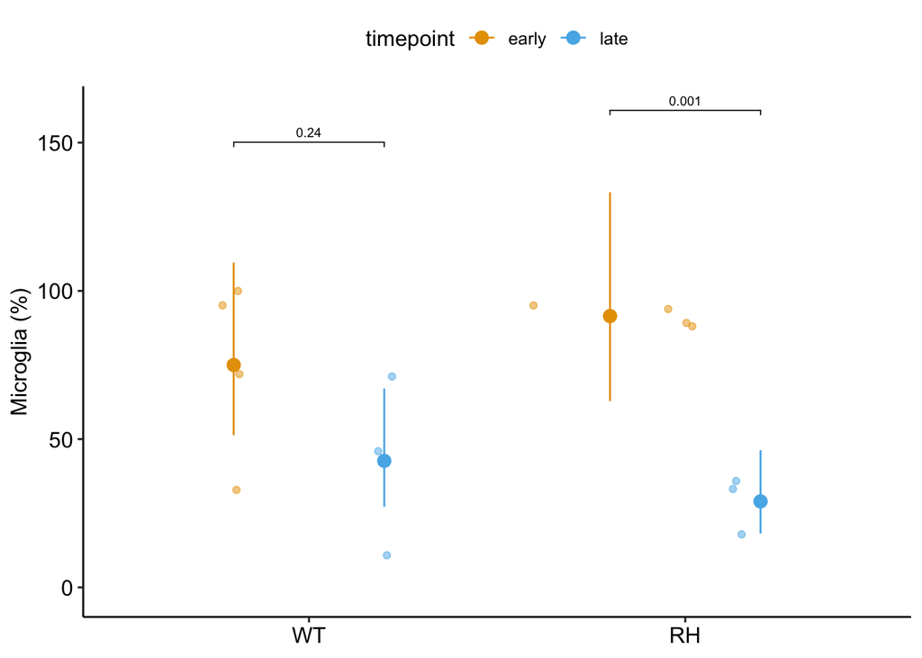

```r
ggplot_the_response(m1, m1_emm, m1_pairs[c(2,5),], # limit to early-late comparisons
                    y_label = "Microglia (%)")
```

**Reproducibility**:

**Better than reproducibility**

First - I said in the assignment to ignore the fact that there are possibly two sources of dependence in the data. The first is that the mice were measured both early and late. I don’t know if these were on the same or different mice. I said to assume separate. But if they were the same, then we’d want to use a pre-post design (which include linear mixed models - see chapter 17). The second is that the source tissue came from 4 donor mice, so donor mouse is a batch. But I said to ignore this too. So here is what I was looking for:

1. Don’t use a neg binomial on percents! This will work okay if the percents are near zero but awful if near 100 as here. Percents can be modeled using a binomial (logistic) model (see below) or even better, use the negative binomial on the counts with the raw data and use the whole amount as an offset.
2. Note that the reproduced CIs go above 100%, which is absurd because percents of wholes cannot be above 100. The problem is a NB models a cound and of course counts *can* be abov 100.
3. Note that the reproduced CIs don’t look right - some seem way too big. This is because a percentage isn’t a count
4. Note that the article CIs DO NOT rise above 100. Something is going on. Clearly they didn’t use a NB on the percent data (I didn’t notice this when creating the assignment). Did they actually fit a binomial and not negative binomial. These are really different. A binomial (logistic) is for responses with two values (0,1) which can represent success or failure of an event, for example survived/died, presence/absence, escaped/caught. Let’s fit a binomial

```r
# convert percent to fraction so values are between 0 and 1
fig2f[, microglia_fraction := microglia_percent/100]
m2 <- glm(microglia_fraction ~ genotype * timepoint,
          family = binomial(link = "logit"),
          data = fig2f)
# non-sandwich errors
m2_emm_0 <- emmeans(m2,
                    specs = c("genotype", "timepoint"),
                  type = "response")
m2_pairs_0 <- contrast(m2_emm_0,
                     method = "revpairwise") |>
  summary(infer = TRUE)
# sandwich errors - use these
m2_emm <- emmeans(m2,
                    specs = c("genotype", "timepoint"),
                    vcov. = vcovHC(m2, type="HC3"),
                  type = "response")
m2_pairs <- contrast(m2_emm,
                     method = "revpairwise") |>
  summary(infer = TRUE)

# compare
m2_emm_0
```

```
##  genotype timepoint  prob    SE  df asymp.LCL asymp.UCL
##  WT       early     0.750 0.217 Inf    0.2378     0.966
##  RH       early     0.915 0.139 Inf    0.2427     0.997
##  WT       late      0.427 0.286 Inf    0.0702     0.880
##  RH       late      0.290 0.262 Inf    0.0326     0.832
##
## Confidence level used: 0.95
## Intervals are back-transformed from the logit scale
```

```r
m2_emm
```

```
##  genotype timepoint  prob     SE  df asymp.LCL asymp.UCL
##  WT       early     0.750 0.1763 Inf     0.322     0.950
##  RH       early     0.915 0.0203 Inf     0.866     0.947
##  WT       late      0.427 0.2131 Inf     0.119     0.804
##  RH       late      0.290 0.0682 Inf     0.176     0.439
##
## Confidence level used: 0.95
## Intervals are back-transformed from the logit scale
```

```r
m2_pairs_0
```

```
##  contrast            odds.ratio     SE  df asymp.LCL asymp.UCL null z.ratio
##  RH early / WT early     3.5882 7.6521 Inf  0.014982     859.4    1   0.599
##  WT late / WT early      0.2481 0.4073 Inf  0.003653      16.8    1  -0.849
##  WT late / RH early      0.0691 0.1479 Inf  0.000284      16.9    1  -1.249
##  RH late / WT early      0.1361 0.2339 Inf  0.001648      11.2    1  -1.161
##  RH late / RH early      0.0379 0.0834 Inf  0.000134      10.8    1  -1.488
##  RH late / WT late       0.5489 0.9477 Inf  0.006500      46.3    1  -0.347
##  p.value
##   0.9324
##   0.8309
##   0.5957
##   0.6518
##   0.4446
##   0.9856
##
## Confidence level used: 0.95
## Conf-level adjustment: tukey method for comparing a family of 4 estimates
## Intervals are back-transformed from the log odds ratio scale
## P value adjustment: tukey method for comparing a family of 4 estimates
## Tests are performed on the log odds ratio scale
```

```r
m2_pairs
```

```
##  contrast            odds.ratio     SE  df asymp.LCL asymp.UCL null z.ratio
##  RH early / WT early     3.5882 3.5016 Inf   0.29249    44.020    1   1.309
##  WT late / WT early      0.2481 0.3180 Inf   0.00921     6.680    1  -1.088
##  WT late / RH early      0.0691 0.0629 Inf   0.00668     0.715    1  -2.938
##  RH late / WT early      0.1361 0.1357 Inf   0.01051     1.764    1  -2.000
##  RH late / RH early      0.0379 0.0160 Inf   0.01285     0.112    1  -7.762
##  RH late / WT late       0.5489 0.5115 Inf   0.05007     6.016    1  -0.644
##  p.value
##   0.5570
##   0.6972
##   0.0174
##   0.1879
##   <.0001
##   0.9178
##
## Confidence level used: 0.95
## Conf-level adjustment: tukey method for comparing a family of 4 estimates
## Intervals are back-transformed from the log odds ratio scale
## P value adjustment: tukey method for comparing a family of 4 estimates
## Tests are performed on the log odds ratio scale
```

Quasibinomial alternative to binomial. This might perform a little better.

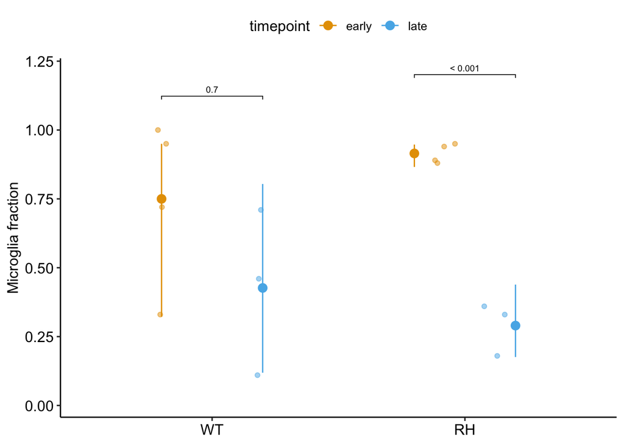

```r
# fit using quasibinomial
m3 <- glm(microglia_fraction ~ genotype * timepoint,
                family = quasibinomial(link = "logit"),
                data = fig2f)
 m3_emm <- emmeans(m3,
                    specs = c("genotype", "timepoint"),
                    vcov. = vcovHC(m3, type="HC3"),
                  type = "response")
m3_pairs <- contrast(m3_emm,
                     method = "revpairwise") |>
  summary()
ggplot_the_response(m2, m2_emm, m2_pairs[c(2,5),], # limit to early-late comparisons
                    y_label = "Microglia fraction")
```

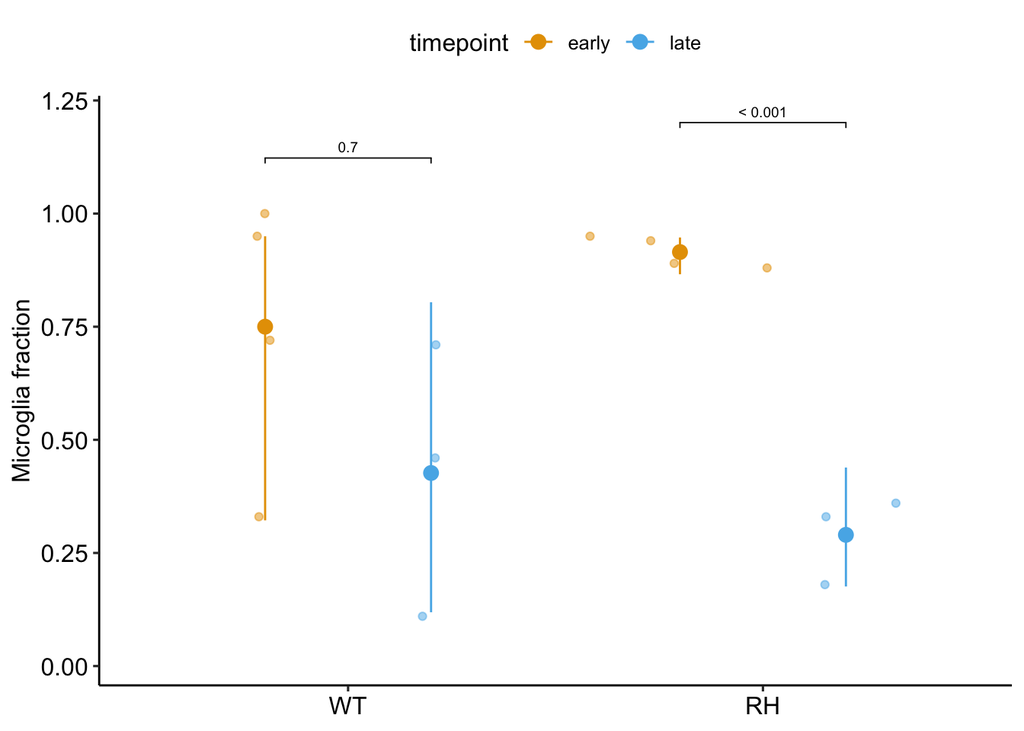

```r
ggplot_the_response(m3, m3_emm, m3_pairs[c(2,5),], # limit to early-late comparisons
                    y_label = "Microglia fraction")
```

Notes

1. 1. For the glm binomial or quasibinomial, use this code from the sandwich package to get better CIs computed from a sandwich estimator of the stanard error (it looks like the authors did this, which is pretty sophisticated - nice job authors!).

vcov. = vcovHC(m2, type=“HC3”)

[See if you can understand bits of this wikipedia article on sandwich estimators](https://en.wikipedia.org/wiki/Heteroskedasticity-consistent_standard_errors)

2. The article used a log10 y axis! Think about this and why this is rediculous. A log-transformed axis is for a measure that is highly skewed over many orders of magnitude (values near zero and in the thousands or millions). Otherwise, The results and plot look like the article. So they (probably) used a binomial and not a negative binomial. The binomial is pretty good but is kinda kludgy and the sandwich estimator is very kludgy (but useful). If you have the raw data, just use the NB with offset!
3. Let’s make the plot look more like Fig 2f from the article. Again, don’t use a log axis for proportion data! It’s really stupid unless you have a bunch of points in the range 0 - 0.01 and then a few above .10 (again, orders of magnitude) - all the fractions here have the same order of magnitude!!!

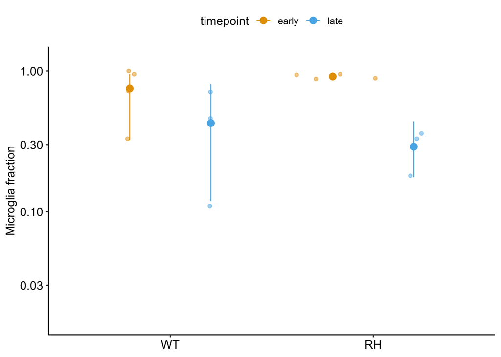

```r
gg <- ggplot_the_response(m2, m2_emm, m2_pairs[c(2,5),], # limit to early-late comparisons
                    y_label = "Microglia fraction") +
  scale_y_continuous(trans='log10')
gg
```

**Is this inference by the authors justified**. No, it is not. The researcher’s state there is a drop in the RH but not the WT but they can’t infer that there is *NOT* a drop in the WT group (p-value for WT group is high) or that the drop is bigger in the RH group (interaction p-value) because the data are too noisy. Note the interaction is not small.

```r
coef(summary(m1))
```

```
##                            Estimate Std. Error    z value      Pr(>|z|)
## (Intercept)               4.3174881  0.1933786 22.3266023 2.038490e-110
## genotypeRH                0.1988509  0.2723775  0.7300561  4.653559e-01
## timepointlate            -0.5640701  0.3010378 -1.8737519  6.096463e-02
## genotypeRH:timepointlate -0.5849730  0.4293346 -1.3625108  1.730367e-01
```

```r
# for the binomial model p-value we need the sandwich estimator of the SE, so use m2_emm from above
wt_early <- c(1,0,0,0)
rh_early <- c(0,1,0,0)
wt_late <- c(0,0,1,0)
rh_late <- c(0,0,0,1)
planned <- list(
  ixn = (rh_late - rh_early) - (wt_late - wt_early) # difference in effect of time in RH and WT groups
)

print("  ")
```

```
## [1] "  "
```

```r
print("binomial model")
```

```
## [1] "binomial model"
```

```r
m2_ixn <- contrast(m2_emm,
                     method = planned) |>
  summary()
m2_ixn
```

```
##  contrast odds.ratio    SE  df null z.ratio p.value
##  ixn           0.153 0.206 Inf    1  -1.391  0.1641
##
## Tests are performed on the log odds ratio scale
```

## Dataset 2: A mechanosensitive peri-arteriolar niche for osteogenesis and lymphopoiesis

**Motivation for this dataset**: This article is amazing because it accounted for lack of independence in due to mouse or litter AND archived mouse and litter ID AND archived all graphpad prism results. This is the model article for archiving data. Thank you authors!

**Source article**: Source article: [Shen, Bo, et al. “A mechanosensitive peri-arteriolar niche for osteogenesis and lymphopoiesis.” Nature 591.7850 (2021): 438-444.](https://www.nature.com/articles/s41586-021-03298-5)

**From the authors**: Leptin Receptor+ (LEPR+) cells are heterogeneous, including skeletal stem cells and osteogenic and adipogenic progenitors, although few markers have been available to distinguish these subsets or to compare their functions. Here we show that expression of an osteogenic growth factor, osteolectin, distinguishes peri-arteriolar LEPR+ cells poised to undergo osteogenesis from peri-sinusoidal LEPR+ cells poised to undergo adipogenesis (but retaining osteogenic potential).

**Author’s reported result**: Furthermore, 11 ± 2.4% of Oln-mTomato−LEPR+ stromal cells but only 5.2 ± 1.3% of Oln-mTomato+LEPR+ cells formed CFU-Fs (Fig. 2b)

**Source File**: mechanosensitive_fig2b.xlsx

**Repro Figure**: 2b

**Response variable**: Percent of cells forming fibroblast Colony Forming Units (CFU-F)

**Assignment**:

1. Reproduce the ANOVA and post-hoc test statistics given by the authors for the analysis in Fig 2b. These results are in the excel file. In your document, report the authors p-values to make the comparison easy to follow.
2. Plot the model using ggplot_the_response. Give the plot pretty x-axis and y-axis labels. See the section in the [Plotting Models](https://www.middleprofessor.com/files/bio413/applied_biostatistics/plotting-models.html#how-to-use-the-plot-the-model-functions) chapter in the textbook on using ggplot_the_response to understand the arguments of the functions. This plot will look something like the published plot but will be a little different and better.

```r
data_from <- "A mechanosensitive peri-arteriolar niche for osteogenesis and lymphopoiesis"
file_name <- "mechanosensitive_fig2b.xlsx"
file_path <- here(data_folder, data_from, file_name)
fig2b <- read_excel(file_path,
#                    sheet = xxx,
                    range = "A1:D19") |>
  data.table()
# create factors with meaningful order of levels
fig2b[, genotype := factor(genotype, levels = c("LepR_pos", "Oln_pos", "Oln_neg" ))]
```

```r
m1 <- aov_4(cells_percent ~ genotype + (genotype | mouse),
              include_aov = TRUE,
              data = fig2b)

m1_emm <- emmeans(m1, specs = "genotype")

m1_pairs <- m1_emm |>
  contrast(method = "revpairwise", adjust = "tukey") |>
  summary(infer = TRUE)
```

**Reproducibility**:

1. Article ANOVA
- ANOVA table SS DF MS F (DFn, DFd) P value
- Treatment (between columns) 121.4 2 60.72 F (1.808, 9.038) = 65.84 P<0.0001
- Individual (between rows) 46.44 5 9.289 F (5, 10) = 10.07 P=0.0012

```r
anova(m1)
```

```
## Anova Table (Type 3 tests)
##
## Response: cells_percent
##          num Df den Df    MSE      F    ges    Pr(>F)
## genotype 1.8077 9.0383 1.0204 65.843 0.6857 5.068e-06 ***
## ---
## Signif. codes:  0 '***' 0.001 '**' 0.01 '*' 0.05 '.' 0.1 ' ' 1
```

Same F (they rounded their p-value but the F is the same so P will be the same given the same DF)

2. Article pairwise comparisons
- Tukey’s multiple comparisons test Mean Diff. 95.00% CI of diff. Significant? Summary Adjusted P Value
- LepR+ vs. LepR+Osteolectin+ 4.833 3.068 to 6.599 Yes *** 0.0007
- LepR+ vs. LepR+Osteolectin- -1.167 -2.720 to 0.3863 No ns 0.1235
- LepR+Osteolectin+ vs. LepR+Osteolectin- -6 -8.058 to -3.942 Yes *** 0.0005

```r
m1_pairs
```

```
##  contrast           estimate    SE df lower.CL upper.CL t.ratio p.value
##  Oln_pos - LepR_pos    -4.83 0.543  5   -6.599    -3.07  -8.907  0.0007
##  Oln_neg - LepR_pos     1.17 0.477  5   -0.386     2.72   2.445  0.1235
##  Oln_neg - Oln_pos      6.00 0.632  5    3.942     8.06   9.487  0.0005
##
## Confidence level used: 0.95
## Conf-level adjustment: tukey method for comparing a family of 3 estimates
## P value adjustment: tukey method for comparing a family of 3 estimates
```

This reproduces exactly.

Note:

I think most biologists trained with linear mixed models would fit the random intercept model. The ANOVA from this reproduces exactly but the contrasts are a little different because the random intercept assumes equal slope.

```r
m2 <- lmer(cells_percent ~ genotype + (1 | mouse), data = fig2b)
m2_aov <- anova(m2)
m2_aov
```

```
## Type III Analysis of Variance Table with Satterthwaite's method
##          Sum Sq Mean Sq NumDF DenDF F value    Pr(>F)
## genotype 121.44  60.722     2    10  65.843 1.751e-06 ***
## ---
## Signif. codes:  0 '***' 0.001 '**' 0.01 '*' 0.05 '.' 0.1 ' ' 1
```

```r
m2_emm <- emmeans(m2, specs = c("genotype"))
m2_pairs <- contrast(m2_emm,
                     method = "revpairwise",
                     adjust = "tukey") |>
  summary(infer = TRUE)
m2_pairs
```

```
##  contrast           estimate    SE df lower.CL upper.CL t.ratio p.value
##  Oln_pos - LepR_pos    -4.83 0.554 10   -6.353    -3.31  -8.717  <.0001
##  Oln_neg - LepR_pos     1.17 0.554 10   -0.353     2.69   2.104  0.1386
##  Oln_neg - Oln_pos      6.00 0.554 10    4.480     7.52  10.822  <.0001
##
## Degrees-of-freedom method: kenward-roger
## Confidence level used: 0.95
## Conf-level adjustment: tukey method for comparing a family of 3 estimates
## P value adjustment: tukey method for comparing a family of 3 estimates
```

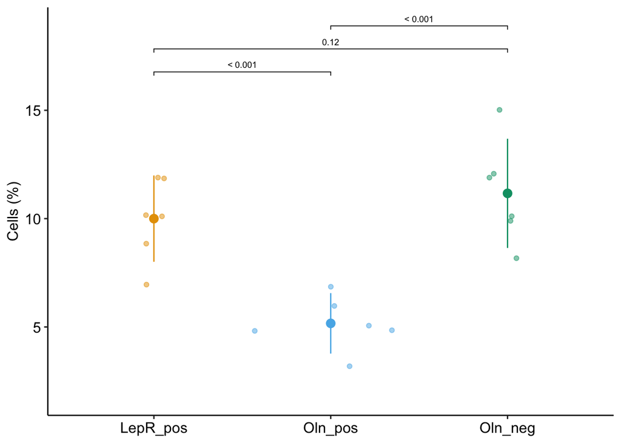

```r
ggplot_the_response(m1, m1_emm, m1_pairs, # limit to early-late comparisons
                    y_label = "Cells (%)")
```

# Better Than Reproducibilty II

## Dataset 3: Amending microbiota by targeting intestinal inflammation with TNF blockade attenuates development of colorectal cancer

**Source article**: [Yang, Y., Gharaibeh, R.Z., Newsome, R.C. and Jobin, C., 2020. Amending microbiota by targeting intestinal inflammation with TNF blockade attenuates development of colorectal cancer. Nature cancer, 1(7), pp.723-734.](https://www.nature.com/articles/s43018-020-0078-7)

**Background**: NC101 strains of E. coli have the clb+ genotype, which produces a gene product that produces Colibactin. Colibactin, in turn, alkylates DNA and induces DNA double-stranded breaks, which leads to Colorectal cancer. Prior findings showed that clb- E. coli have reduced tumor growth in pathogen-free environment. The researchers want to know how clb+ and clb- effect tumor growth in normal microbial environment of mouse gut.

**Author’s reported result** “Notably, NC101-colonized mice developed significantly more colon tumors than K12 and ΔclbP-colonized mice (P = 0.0027 and 0.0020, respectively), with no difference observed between the latter two groups (Fig. 1b,c)”

**Source Data**: amending_microbiota_fig1c.xlsx

**Response variable**: tumor_count (the number of colorectal tumors)

**Researcher’s Analysis**: The researchers used a Dunn test, which is a non-parametric test, based on ranks, for pairwise comparisons. The researchers also used the bonferroni adjustment of the three p-values.

You can do better than this!

(Note: I can reproduce their results but I’m not asking you to do this because I don’t want you to practice methods that aren’t best practice!)

**Assignment**

1. Reanalyze the data, using a better practice than what the author’s did.
2. Plot the model using ggplot_the_response. Give the plot pretty x-axis and y-axis labels. See the section in the [Plotting Models](https://www.middleprofessor.com/files/bio413/applied_biostatistics/plotting-models.html#how-to-use-the-plot-the-model-functions) chapter in the textbook on using ggplot_the_response to understand the arguments of the functions. This plot will look something like the published plot but will be a little different and better.
3. In your annotation, address why your analysis is better than what the researchers did, that is “better than reproducibilty”

```r
data_from <- "Amending microbiota by targeting intestinal inflammation with TNF blockade attenuates development of colorectal cancer"
file_name <- "amending_microbiota_fig1c.xlsx"
file_path <- here(data_folder, data_from, file_name)
fig1c <- read_excel(file_path,
#                    sheet = xxx,
                    range = "A1:B42") |>
  data.table()
# create factors with meaningful order of levels
fig1c[, treatment := factor(treatment, levels = c("K12", "NC101", "ΔclbP"))]
```

```r
m1 <- glm.nb(tumor_count ~ treatment,
              data = fig1c)

m1_emm <- emmeans(m1, specs = "treatment", type = "response")

m1_pairs <- m1_emm |>
  contrast(method = "revpairwise") |>
  summary(infer = TRUE)
```

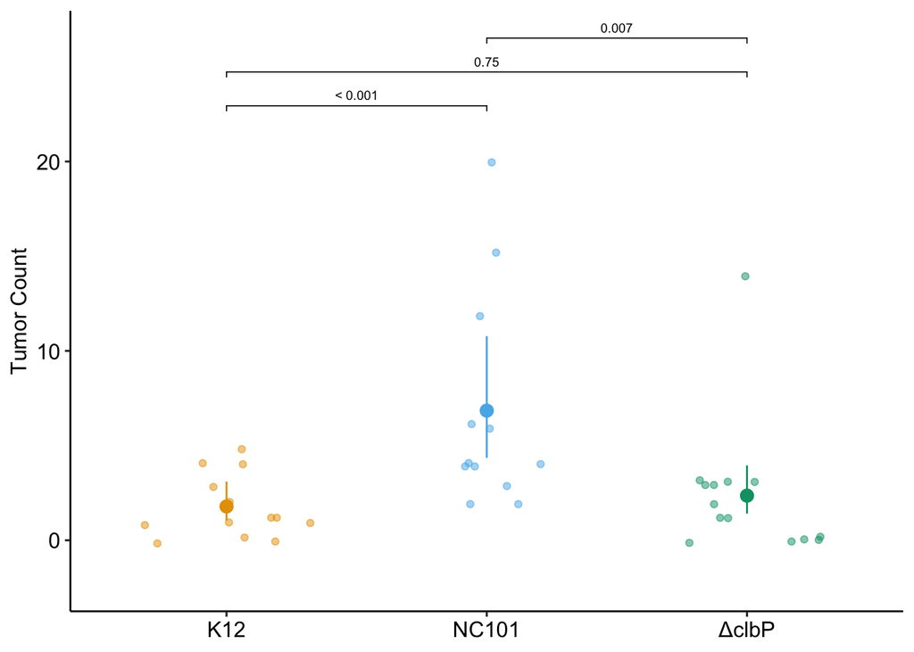

```r
ggplot_the_response(m1, m1_emm, m1_pairs, # limit to early-late comparisons
                    y_label = "Tumor Count")
```

1. Reanalyze the data: I used GLM with negative binomial distribution.
2. Plot the model using ggplot_the_response. See above
3. In your annotation, address why your analysis is better than what the researchers did, that is “better than reproducibilty” – 1) A GLM for count data using a negative binomial distribution has more power than a non-parametric test using ranks and 2) I would use non-adjusted p-values because each of these contrasts is a different family and answer a different question.

## Dataset 4: Glutamatergic synaptic input to glioma cells drives brain tumour progression

Source article: [Venkataramani, V., Tanev, D. I., Strahle, C., Studier-Fischer, A., Fankhauser, L., Kessler, T., … & Kuner, T. (2019). Glutamatergic synaptic input to glioma cells drives brain tumour progression. Nature, 573(7775), 532-538.](https://www.nature.com/articles/s41586-019-1564-x)

**Background**: The researchers are investigating the role of neurogliomal synapses (NGS) on invasion of glioblastoma (GB) cells. Synaptic communication is controlled by glutamatergic AMPA receptors (AMPAR).

**Author’s reported result** When AMPAR signalling was thus genetically perturbed, in vivo GB cell invasion was reduced (Fig. 5f, g, Extended Data Fig. 7q).

**Source Data**: glutamatergic_fig5g.xlsx

**Response variable**: Invasion speed of GB cells.

**Researcher’s Analysis**: “P values determined by two-sided Mann–Whitney test”

You can do better than this!

(Note: I can reproduce their results but I’m not asking you to do this because I don’t want you to practice methods that aren’t best practice!)

**Assignment**

1. Reanalyze the data, using a better practice than what the author’s did. *first, there is pseudoreplication. There are subsampled values within region and then region within mouse. We could ignore region and just average over mouse (using mouse as a random intercept) or we could average within region within mouse (mouse:region) and mouse. Either way, we’ed want to fit a model with lmer.

m1 - a random intercept model (1 | mouse) to account for pseudoreplication within mouse but ignoring region

m2 - two random intercepts (1 | mouse) and (1 | mouse:region). Should be very similar to m1.

either m1 and m2 are good and they differ only in how we want to average the subsampled replicates (ignoring or accounting for the fact that technical replicates were sampled in differnt regions of the brain)

*Also, the data are right skewed and a qq plot shows poor fit by lm. This might disappear using only the means so I’m less concerned about this. But if we want to do this then we can

m3 - glm mixed model with gamma family

m4 - glm model on the values averaged within mouse (averaged within region and then these averaged within mouse)

All of these models give similar results

2. Plot the model using ggplot_the_response. Give the plot pretty x-axis and y-axis labels. See the section in the [Plotting Models](https://www.middleprofessor.com/files/bio413/applied_biostatistics/plotting-models.html#how-to-use-the-plot-the-model-functions) chapter in the textbook on using ggplot_the_response to understand the arguments of the functions. This plot will look something like the published plot but will be a little different and better.
3. In your annotation, address why your analysis is better than what the researchers did, that is “better than reproducibilty” (see no. 1 above)

```r
data_from <- "Glutamatergic synaptic input to glioma cells drives brain tumour progression"
file_name <- "glutamatergic_fig5g.xlsx"
file_path <- here(data_folder, data_from, file_name)
fig5g <- read_excel(file_path,
#                    sheet = xxx,
                    range = "A1:D209") |>
  data.table()
# create factors with meaningful order of levels
fig5g[, genotype := factor(genotype, levels = c("Control","DN"))]
```

```r
m1 <- lmer(invasion_speed ~ genotype + (1 | mouse),
              data = fig5g)

m1_emm <- emmeans(m1, specs = "genotype")

m1_pairs <- m1_emm |>
  contrast(method = "revpairwise") |>
  summary(infer = TRUE)
```

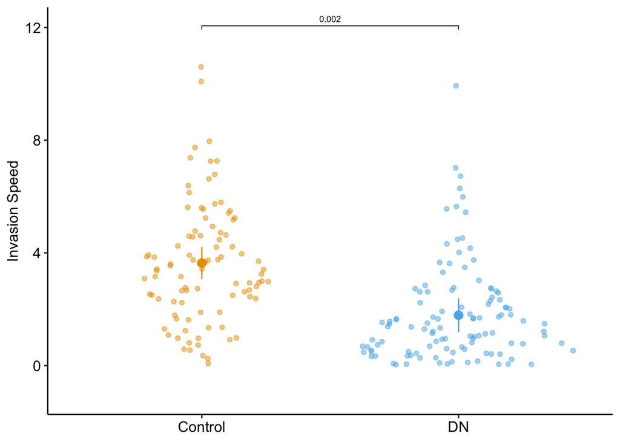

```r
ggplot_the_response(m1, m1_emm, m1_pairs,
                    y_label = "Invasion Speed")
```

```r
# alternative to account for region nested within mouse
m2 <- lmer(invasion_speed ~ genotype + (1 | mouse) + (1 | mouse:region),
              data = fig5g)
m2_emm <- emmeans(m2, specs = "genotype")

m2_pairs <- m2_emm |>
  contrast(method = "revpairwise") |>
  summary(infer = TRUE)

# compare with m1
m1_pairs
```

```
##  contrast     estimate    SE  df lower.CL upper.CL t.ratio p.value
##  DN - Control    -1.85 0.325 5.2    -2.68    -1.02  -5.693  0.0021
##
## Degrees-of-freedom method: kenward-roger
## Confidence level used: 0.95
```

```r
m2_pairs
```

```
##  contrast     estimate    SE   df lower.CL upper.CL t.ratio p.value
##  DN - Control    -1.82 0.336 4.79     -2.7   -0.946  -5.419  0.0033
##
## Degrees-of-freedom method: kenward-roger
## Confidence level used: 0.95
```

A plot to see the batched data

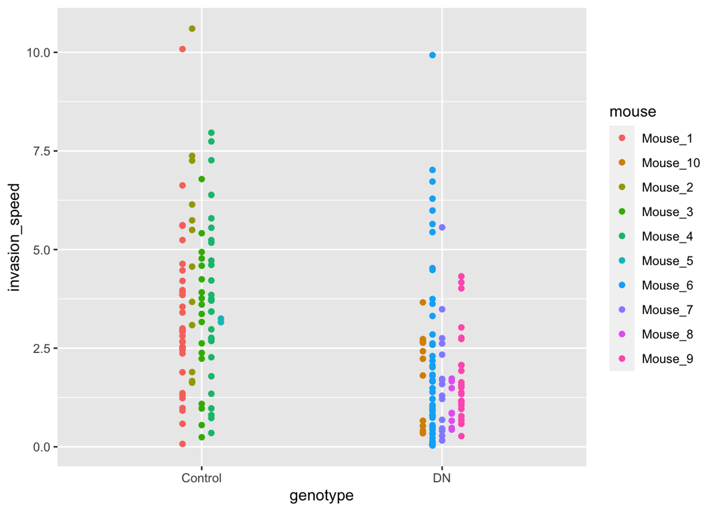

```r
ggplot(data = fig5g,
       aes(x = genotype,
           y = invasion_speed,
           color = mouse)) +
  geom_point(position = position_dodge(width = 0.2))
```

Use mouse means to check the model

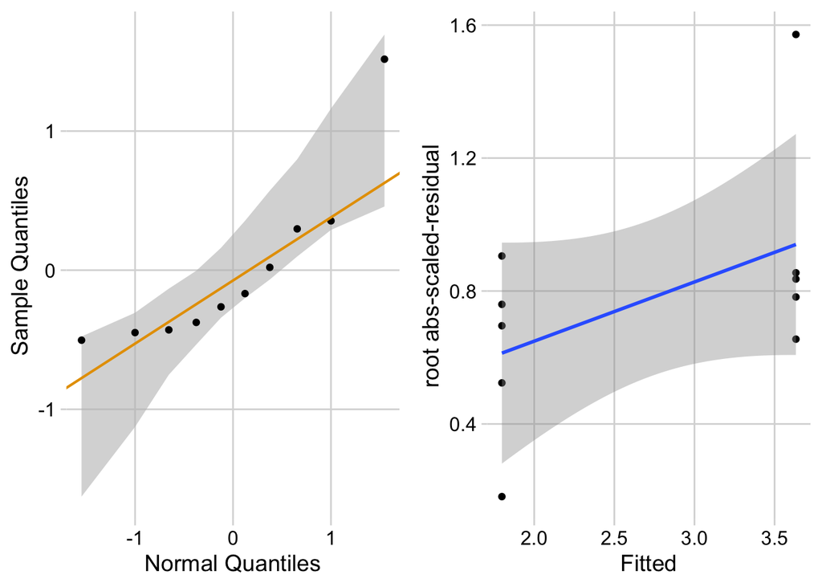

```r
# first get means within region within mouse
fig5g_region_means <- fig5g[, .(invasion_speed = mean(invasion_speed)),
                            by = .(genotype, mouse, region)]
# second average regions within mouse
fig5g_means <- fig5g_region_means[, .(invasion_speed = mean(invasion_speed)),
                            by = .(genotype, mouse)]
m0 <- lm(invasion_speed ~ genotype, data = fig5g_means)
ggcheck_the_model(m0)
```

An alternative glm mixed model! and a glm of the averaged data for comparison.

```r
m3 <- glmmTMB(invasion_speed ~ genotype + (1 | mouse),
              family = Gamma(link = "log"),
              data = fig5g)
m3_emm <- emmeans(m3, specs = "genotype", type = "response")
m3_pairs <- contrast(m3_emm,
                     method = "revpairwise") |>
  summary(infer = TRUE)
```

```r
m4 <- glm(invasion_speed ~ genotype,
              family = Gamma(link = "log"),
              data = fig5g_means)
m4_emm <- emmeans(m4, specs = "genotype", type = "response")
m4_pairs <- contrast(m4_emm,
                     method = "revpairwise") |>
  summary(infer = TRUE)
```

```r
m1_pairs
```

```
##  contrast     estimate    SE  df lower.CL upper.CL t.ratio p.value
##  DN - Control    -1.85 0.325 5.2    -2.68    -1.02  -5.693  0.0021
##
## Degrees-of-freedom method: kenward-roger
## Confidence level used: 0.95
```

```r
m2_pairs
```

```
##  contrast     estimate    SE   df lower.CL upper.CL t.ratio p.value
##  DN - Control    -1.82 0.336 4.79     -2.7   -0.946  -5.419  0.0033
##
## Degrees-of-freedom method: kenward-roger
## Confidence level used: 0.95
```

```r
m3_pairs
```

```
##  contrast     ratio     SE  df lower.CL upper.CL null t.ratio p.value
##  DN / Control 0.505 0.0593 204      0.4    0.636    1  -5.825  <.0001
##
## Confidence level used: 0.95
## Intervals are back-transformed from the log scale
## Tests are performed on the log scale
```

```r
m4_pairs
```

```
##  contrast     ratio     SE df lower.CL upper.CL null t.ratio p.value
##  DN / Control 0.495 0.0676  8    0.361    0.678    1  -5.152  0.0009
##
## Confidence level used: 0.95
## Intervals are back-transformed from the log scale
## Tests are performed on the log scale
```

Note that the first two contrasts are differences and the last two are ratios.